# R Notebook

# Libraries

```r
library(slider)
```

# Questions and notes

- What is the pattern of bike hires over time (e.g. within a year, month, week, or day)? -Explore using plots with time series data and bike hire counts/use duration in mins
- Do bike hire patterns differ between bike rider demographics? (e.g. gender, type of trip, age)? -Gender and bike hire counts (include type of trip) - stacked bar graph -Gender and use duration in mins(include type of trip) - box plot -Age and use duration in mins - scatter plot -Age and bike hire counts - need age ranges for this - stacked bar graph (with type of trip)
- What is the geographical spread of the start points of bike hires? -Leaflet plot (can we maybe make the stations vary in size by the number of bike hires?)
- Any other insights?

## Problems discovered during exploration

- Some very large values in use_duration_mins representing use over multiple days
- The dataset is biased because the sample is only drawn from Jersey City -Users could probably be identified from this data and their address (either home or place of work) could be approximated by the start/end points of their journey.

```r
bikes_data <- nyc_bikes

bikes_data %>% head()
```

| bike_id | start_time | stop_time | start_station | start_lat | start_long | end_station | end_lat | end_long | type | birth_year | gender |
| --- | --- | --- | --- | --- | --- | --- | --- | --- | --- | --- | --- |
| 26301 | 2018-02-26 19:11:03 | 2018-02-26 19:15:40 | 3186 | 40.71959 | -74.04312 | 3203 | 40.72760 | -74.04425 | Subscriber | 1986 | Male |
| 26301 | 2018-02-27 07:52:49 | 2018-02-27 07:58:13 | 3203 | 40.72760 | -74.04425 | 3202 | 40.72722 | -74.03376 | Subscriber | 1979 | Male |
| 26301 | 2018-02-27 12:03:27 | 2018-02-27 12:04:54 | 3202 | 40.72722 | -74.03376 | 3638 | 40.72429 | -74.03548 | Subscriber | 1963 | Male |
| 26301 | 2018-02-27 13:53:51 | 2018-02-27 14:21:04 | 3638 | 40.72429 | -74.03548 | 3638 | 40.72429 | -74.03548 | Subscriber | 1984 | Male |
| 26301 | 2018-02-27 14:30:42 | 2018-02-27 14:33:11 | 3638 | 40.72429 | -74.03548 | 3187 | 40.72112 | -74.03805 | Subscriber | 1980 | Male |
| 26301 | 2018-02-27 16:31:04 | 2018-02-27 16:33:27 | 3187 | 40.72112 | -74.03805 | 3638 | 40.72429 | -74.03548 | Subscriber | 1980 | Male |

## Create new variables for analysis

```r
#create variables for date, month, weekday, year from start_time
bikes_data <- bikes_data %>%
  mutate(start_date = date(start_time),
         start_month = month(start_time, label = TRUE),
         start_year = year(start_time),
         start_wday = wday(start_time, label = TRUE),
         .after = start_time)
```

```r
#create variable that extracts the time from start_time
bikes_data <- bikes_data %>%
  mutate(start_time_clock = as_hms(ymd_hms(start_time)), .after = start_time)
```

```r
#create variable for customer/subscriber age
bikes_data <- bikes_data %>%
  mutate(age = start_year - birth_year, .after = birth_year)
```

```r
#create variable for use duration in minutes
bikes_data <- bikes_data %>%
  mutate(use_period = as.period(stop_time - start_time),
         use_duration_mins = as.numeric(use_period, "minutes"))
```

## Fix problems identified in dataset

```r
#look at top values in use_duration_mins
bikes_data %>%
  slice_max(use_duration_mins, n = 10)
```

[output not shown]

There are two very high values here that show use_duration_mins as over 5000. After looking at the lat/long for the start and end stations, they are fairly close together. It is likely that these long use periods are the result of returning the bikes incorrectly (the website states that you have to wait for the green light). So if the bikes weren’t returned correctly, the stop_time wouldn’t be recorded until someone (e.g. another customer or someone who maintains the bikes for the company) returned it correctly. Since there are some high values in the dataset that will pull the mean higher, I have chosen to impute them with the median duration for the subscribers group (since both are subscribers).

```r
bikes_data %>%
  mutate(use_duration_mins = if_else(
    use_duration_mins > 5000,
    median_use_duration_subscriber,
    use_duration_mins
  )) %>%
  slice_max(use_period, n = 10)
```

| bike_id | start_time | start_date | start_month | start_year | start_wday | stop_time | start_station | start_lat | start_long | end_station | end_lat | end_long | type | birth_year | age | gender | use_period | use_duration_mins |
| --- | --- | --- | --- | --- | --- | --- | --- | --- | --- | --- | --- | --- | --- | --- | --- | --- | --- | --- |
| 29477 | 2018-10-19 18:20:53 | 2018-10-19 | Oct | 2018 | Fri | 2018-10-23 13:40:32 | 3183 | 40.71625 | -74.03346 | 3426 | 40.70965 | -74.06860 | Subscriber | 1996 | 22 | Unknown | 3d 19H 19M 38.8960001468658S | 5.586933 |
| 29522 | 2018-11-16 21:03:13 | 2018-11-16 | Nov | 2018 | Fri | 2018-11-20 10:09:19 | 3202 | 40.72722 | -74.03376 | 3426 | 40.70965 | -74.06860 | Subscriber | 1986 | 32 | Female | 3d 13H 6M 5.80900001525879S | 5.586933 |
| 29477 | 2018-07-14 12:23:37 | 2018-07-14 | Jul | 2018 | Sat | 2018-07-14 22:36:52 | 3267 | 40.71242 | -74.03853 | 3276 | 40.71458 | -74.04282 | Customer | 1969 | 49 | Unknown | 10H 13M 15.3650000095367S | 613.256083 |
| 29522 | 2018-07-07 01:20:18 | 2018-07-07 | Jul | 2018 | Sat | 2018-07-07 09:18:50 | 3192 | 40.71124 | -74.05570 | 3220 | 40.73496 | -74.05950 | Customer | 1969 | 49 | Unknown | 7H 58M 31.2549998760223S | 478.520917 |
| 26301 | 2018-03-11 08:57:02 | 2018-03-11 | Mar | 2018 | Sun | 2018-03-11 16:11:08 | 3207 | 40.73760 | -74.05248 | 3211 | 40.72153 | -74.04630 | Customer | 1982 | 36 | Male | 7H 14M 6.29900002479553S | 434.104983 |
| 29477 | 2018-08-04 13:35:24 | 2018-08-04 | Aug | 2018 | Sat | 2018-08-04 18:41:29 | 3225 | 40.72366 | -74.06419 | 3214 | 40.71277 | -74.03649 | Subscriber | 1991 | 27 | Female | 5H 6M 5.7960000038147S | 306.096600 |
| 29506 | 2018-10-13 06:14:40 | 2018-10-13 | Oct | 2018 | Sat | 2018-10-13 10:46:19 | 3206 | 40.73117 | -74.05757 | 3694 | 40.71113 | -74.07890 | Subscriber | 1990 | 28 | Male | 4H 31M 38.8359999656695S | 271.647267 |
| 26301 | 2018-07-16 07:53:14 | 2018-07-16 | Jul | 2018 | Mon | 2018-07-16 11:45:46 | 3481 | 40.71649 | -74.04105 | 3638 | 40.72429 | -74.03548 | Customer | 1969 | 49 | Unknown | 3H 52M 32.7300000190735S | 232.545500 |
| 26301 | 2018-07-13 16:38:33 | 2018-07-13 | Jul | 2018 | Fri | 2018-07-13 20:14:18 | 3198 | 40.74872 | -74.04044 | 3198 | 40.74872 | -74.04044 | Customer | 1969 | 49 | Unknown | 3H 35M 44.5739998817444S | 215.742900 |
| 31735 | 2018-04-22 16:56:34 | 2018-04-22 | Apr | 2018 | Sun | 2018-04-22 20:25:26 | 3184 | 40.71415 | -74.03355 | 3205 | 40.71654 | -74.04964 | Customer | 1969 | 49 | Unknown | 3H 28M 52.4059998989105S | 208.873433 |

[output not shown]

[output not shown]

```r
#overwrite age to change the high values
bikes_data <- bikes_data %>%
  mutate(age = start_year - birth_year, .after = birth_year)
```

```r
write_csv("clean_bikes_data.csv")
```

```
Error in write_delim(x, file, delim = ",", na = na, append = append, col_names = col_names,  :
  is.data.frame(x) is not TRUE
```

## Explore using plots

### Demographic variables and use_duration_mins

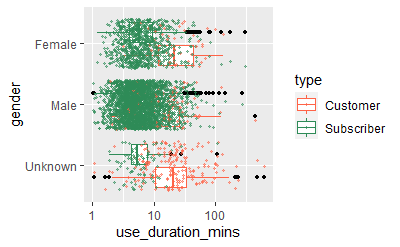

```r
bikes_data %>%
  ggplot(aes(x = use_duration_mins,
             y = gender,
             color = type)) +
  geom_boxplot(outlier.colour = "black", outlier.size = 1) +
  geom_jitter(size = 0.7, alpha = 0.5) +
  scale_color_manual(values = c("tomato", "seagreen")) +
  scale_x_log10()
```

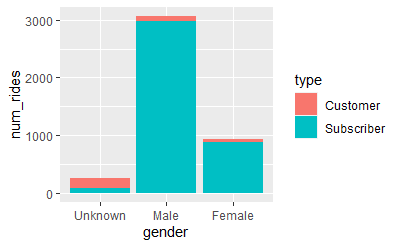

```r
as.tibble(bikes_data) %>%
  group_by(gender, type) %>%
  summarise(num_rides = n()) %>%
  ggplot(aes(x = gender,
             y = num_rides,
             fill = type)) +
  geom_col() +
  scale_color_manual(values = c("tomato", "seagreen"))
```

```r
bikes_data %>%
  ggplot(aes(x = use_duration_mins)) +
  geom_histogram(col = "white") +
  facet_wrap(~gender) +
  scale_x_log10()
```

[output not shown]

[output not shown]

[output cut: 2 more lines]

```r
  ggsave(filename = "annual_bike_hire_2018.png")
```

[output not shown]

```r
bikes_data <- bikes_data %>%
  mutate(start_time_hour = hour(start_time_clock), .after = start_time_clock)
```

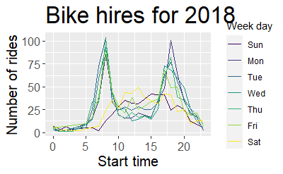

```r
as.tibble(bikes_data) %>%
  group_by(start_wday, start_time_hour) %>%
  summarise(num_rides = n()) %>%
  ggplot(aes(x = start_time_hour,
         y = num_rides)) +
  geom_line(aes(colour = start_wday)) +
  labs(x = "Start time",
       y = "Number of rides",
       colour = "Week day") +
  ggtitle("Bike hires for 2018") +
    theme(plot.title = element_text(size = 25),
          axis.text = element_text(size = 12),
          axis.title = element_text(size = 15))
```

```r
NA
```

```r
ggsave("weekday_weekend_hires.png")
```

```r
as.tibble(bikes_data) %>%
  select(start_station, start_lat, start_long) %>%
  group_by(start_station, start_lat, start_long) %>%
  summarise(num_rides = n()) %>%
  arrange(desc(num_rides))
```

| start_station | start_lat | start_long | num_rides |
| --- | --- | --- | --- |
| 3186 | 40.71959 | -74.04312 | 434 |
| 3203 | 40.72760 | -74.04425 | 278 |
| 3195 | 40.73074 | -74.06378 | 250 |
| 3183 | 40.71625 | -74.03346 | 221 |
| 3202 | 40.72722 | -74.03376 | 181 |
| 3639 | 40.71925 | -74.03423 | 146 |
| 3213 | 40.71849 | -74.04773 | 132 |
| 3199 | 40.72874 | -74.03211 | 126 |
| 3276 | 40.71458 | -74.04282 | 126 |
| 3211 | 40.72153 | -74.04630 | 116 |

[output cut: 42 more lines]

```r
as.tibble(bikes_data) %>%
  select(start_station, start_lat, start_long) %>%
  group_by(start_station, start_lat, start_long) %>%
  summarise(num_rides = n()) %>%
  leaflet() %>%
  addTiles() %>%
  addCircles(
    lng = ~start_long,
    lat = ~start_lat,
    radius = ~num_rides,
    popup = ~paste0("Station number: ", start_station,
                    " Number of rides:", num_rides)
  )
```

[interactive chart not shown]

```r
NA
```

```r
as.tibble(bikes_data) %>%
  select(end_station, end_lat, end_long) %>%
  group_by(end_station, end_lat, end_long) %>%
  summarise(num_rides = n()) %>%
  leaflet() %>%
  addTiles() %>%
  addCircles(
    lng = ~end_long,
    lat = ~end_lat,
    radius = ~num_rides,
    popup = ~paste0("Station number: ", end_station,
                    " Number of rides:", num_rides)
  )
```

[interactive chart not shown]

```r
NA
```

```r
as.tibble(bikes_data) %>%
  select(start_station, start_wday, start_time_hour) %>%
  group_by(start_station, start_wday, start_time_hour) %>%
  summarise(num_rides = n()) %>%
  arrange(desc(num_rides))
```

| start_station | start_wday | start_time_hour | num_rides |
| --- | --- | --- | --- |
| 3186 | Mon | 18 | 22 |
| 3186 | Tue | 18 | 22 |
| 3186 | Thu | 18 | 21 |
| 3195 | Thu | 18 | 19 |
| 3186 | Wed | 18 | 18 |
| 3186 | Mon | 19 | 16 |
| 3186 | Wed | 17 | 15 |
| 3186 | Thu | 17 | 15 |
| 3203 | Mon | 8 | 15 |
| 3195 | Mon | 18 | 14 |

[output cut: 990 more lines]